# Practica6

David M. Villalobo

2023-04-09

## Ej 1

Cargamos las siguientes librerías: MASS, caret, stats, olsrr, kableExtra, knitrr, rmarkdown.

```r
library(MASS)
library(caret)
library(stats)
library(olsrr)
library(kableExtra)
library(knitr)
library(rmarkdown)
```

## Ej 2

Creamos 2 variables almacenadas como vector: “y_cuentas” y “x_distancia”.

```r
y_cuentas <- c(110,2,6,98,40,94,31,5,8,10)
x_distancia <- c(1.1,100.2,90.3,5.4,57.5,6.6,34.7,65.8,57.9,86.1)
```

## Ej 3

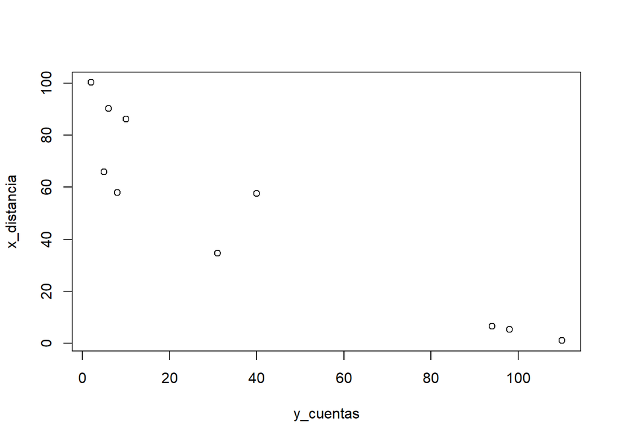

```r
plot(y_cuentas, x_distancia)
```

```r
cor.test(y_cuentas, x_distancia)
```

```
##
##  Pearson's product-moment correlation
##
## data:  y_cuentas and x_distancia
## t = -6.8847, df = 8, p-value = 0.0001265
## alternative hypothesis: true correlation is not equal to 0
## 95 percent confidence interval:
##  -0.9824414 -0.7072588
## sample estimates:
##        cor
## -0.9249824
```

## Ej 4

X es la variable explicativa, no tiene forma de campana, por lo que no es normal, la regresión no se cumple siempre. Con 10 variables, tenemos pocos datos, el shapiro.test no es fiable, da una conclusión no valida, ya que da como resultado que es normal (p-value mayor de 0.05) y eso es falso.

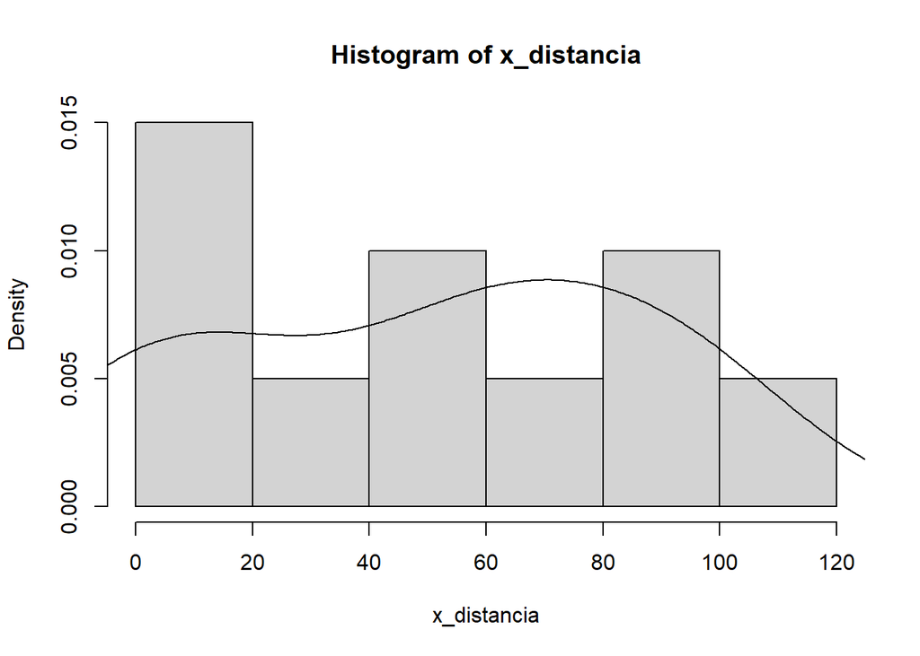

```r
hist(x_distancia, probability = TRUE)
lines(density(x_distancia))
```

```r
shapiro.test(x_distancia)
```

```
##
##  Shapiro-Wilk normality test
##
## data:  x_distancia
## W = 0.90687, p-value = 0.2602
```

## Ej 5

Multiplicamos las variables con * y lo nombramos xy.

```r
xy <- y_cuentas*x_distancia
xy
```

```
##  [1]  121.0  200.4  541.8  529.2 2300.0  620.4 1075.7  329.0  463.2  861.0
```

## Ej 6

Elevamos al cuadrado la variable x, y le otorgamos el nombre x_cuadrado.

```r
x_cuadrado <- x_distancia^2
x_cuadrado
```

```
##  [1]     1.21 10040.04  8154.09    29.16  3306.25    43.56  1204.09  4329.64
##  [9]  3352.41  7413.21
```

## Ej 7

Creamos un dataframe llamado tabla_datos con las variables creadas hasta ahora.

```r
tabla_datos <- data.frame(y_cuentas, x_distancia, xy, x_cuadrado)
tabla_datos
```

```
##    y_cuentas x_distancia     xy x_cuadrado
## 1        110         1.1  121.0       1.21
## 2          2       100.2  200.4   10040.04
## 3          6        90.3  541.8    8154.09
## 4         98         5.4  529.2      29.16
## 5         40        57.5 2300.0    3306.25
## 6         94         6.6  620.4      43.56
## 7         31        34.7 1075.7    1204.09
## 8          5        65.8  329.0    4329.64
## 9          8        57.9  463.2    3352.41
## 10        10        86.1  861.0    7413.21
```

## Ej 8

Visualizamos el dataframe anteriormente creado como una tabla, gracias a la librería kableExtra, primero esterilizamos el dataframe y luego la ejecutamos.

```r
kbl(tabla_datos)%>%
  kable_minimal()
```

| y_cuentas | x_distancia | xy | x_cuadrado |
| --- | --- | --- | --- |
| 110 | 1.1 | 121.0 | 1.21 |
| 2 | 100.2 | 200.4 | 10040.04 |
| 6 | 90.3 | 541.8 | 8154.09 |
| 98 | 5.4 | 529.2 | 29.16 |
| 40 | 57.5 | 2300.0 | 3306.25 |
| 94 | 6.6 | 620.4 | 43.56 |
| 31 | 34.7 | 1075.7 | 1204.09 |
| 5 | 65.8 | 329.0 | 4329.64 |
| 8 | 57.9 | 463.2 | 3352.41 |
| 10 | 86.1 | 861.0 | 7413.21 |

## Ej 9

Realizamos el sumatorio de los valores almacenados en cada una de las 4 columnas. Para ello utilizamos la función sum más el simbolo $ para especificar los valores de que columna queremos sumar.

```r
sum_y <- sum(tabla_datos$y_cuentas)
sum_y
```

```
## [1] 404
```

```r
sum_x <- sum(tabla_datos$x_distancia)
sum_x
```

```
## [1] 505.6
```

```r
sum_xy <- sum(tabla_datos$xy)
sum_xy
```

```
## [1] 7041.7
```

```r
sum_xcuadrado <- sum(tabla_datos$x_cuadrado)
sum_xcuadrado
```

```
## [1] 37873.66
```

## Ej 10

Creamos un vector con los resultados de los sumatorios anteriores, para añadirlos a un dataframe ya existente con rbind(). Le damos un nombre diferente al dataframe para crear uno nuevo sin eliminar el original. Con rownames() indicamos que contiene la nueva fila añadida.

```r
sum_total <- c(sum_y, sum_x, sum_xy, sum_xcuadrado)
sum_total
```

```
## [1]   404.00   505.60  7041.70 37873.66
```

```r
tabla_datos2 <- rbind(tabla_datos, sum_total)
tabla_datos2
```

```
##    y_cuentas x_distancia     xy x_cuadrado
## 1        110         1.1  121.0       1.21
## 2          2       100.2  200.4   10040.04
## 3          6        90.3  541.8    8154.09
## 4         98         5.4  529.2      29.16
## 5         40        57.5 2300.0    3306.25
## 6         94         6.6  620.4      43.56
## 7         31        34.7 1075.7    1204.09
## 8          5        65.8  329.0    4329.64
## 9          8        57.9  463.2    3352.41
## 10        10        86.1  861.0    7413.21
## 11       404       505.6 7041.7   37873.66
```

```r
rownames(tabla_datos2)[11] <- "sumatorio"
rownames(tabla_datos2)[11]
```

```
## [1] "sumatorio"
```

```r
tabla_datos2
```

```
##           y_cuentas x_distancia     xy x_cuadrado
## 1               110         1.1  121.0       1.21
## 2                 2       100.2  200.4   10040.04
## 3                 6        90.3  541.8    8154.09
## 4                98         5.4  529.2      29.16
## 5                40        57.5 2300.0    3306.25
## 6                94         6.6  620.4      43.56
## 7                31        34.7 1075.7    1204.09
## 8                 5        65.8  329.0    4329.64
## 9                 8        57.9  463.2    3352.41
## 10               10        86.1  861.0    7413.21
## sumatorio       404       505.6 7041.7   37873.66
```

## Ej 11

Utilizamos lm() para calcular los datos que necesitemos para obtener la recta de regresión. Con summary() obtenemos los datos necesarios para la recta de regresión. Los datos principales serían 95.37 y -1.087. En la ecuación quedaría así:

$$B_0 -> y - B_1 · x_1 + Σ_1$$
$$Y_0 = 95.37 - 1.087 · x_1 +
Σ_1$$

```r
modelo <- lm(y_cuentas ~ x_distancia, data = tabla_datos)
summary(modelo)
```

```
##
## Call:
## lm(formula = y_cuentas ~ x_distancia, data = tabla_datos)
##
## Residuals:
##     Min      1Q  Median      3Q     Max
## -26.644 -12.672   7.693   8.730  15.825
##
## Coefficients:
##             Estimate Std. Error t value Pr(>|t|)
## (Intercept)  95.3710     9.7188   9.813 9.77e-06 ***
## x_distancia  -1.0872     0.1579  -6.885 0.000126 ***
## ---
## Signif. codes:  0 '***' 0.001 '**' 0.01 '*' 0.05 '.' 0.1 ' ' 1
##
## Residual standard error: 17.52 on 8 degrees of freedom
## Multiple R-squared:  0.8556, Adjusted R-squared:  0.8375
## F-statistic:  47.4 on 1 and 8 DF,  p-value: 0.0001265
```

## Ej 12

Creamos una nube de puntos con plot() y añadimos la recta de regresión con abline().

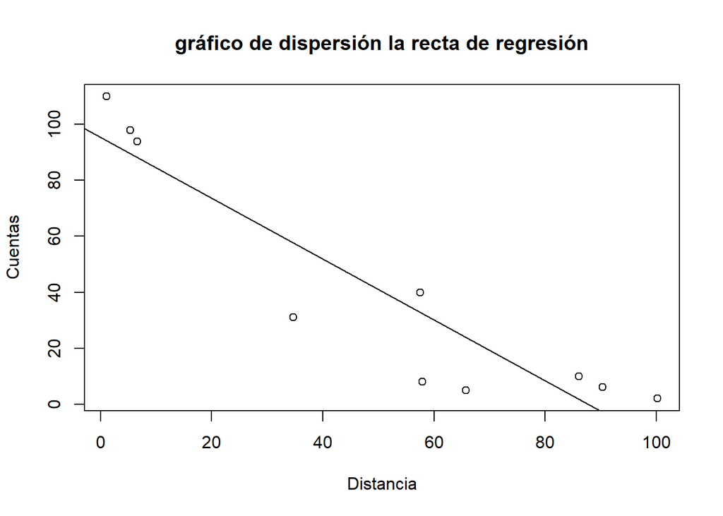

```r
plot(y_cuentas ~ x_distancia, main = "gráfico de dispersión la recta de regresión", ylab = "Cuentas", xlab = "Distancia")
abline(modelo)
```

## Ej 13

Los residuos de un modelo se refieren a las diferencias entre los valores observados y los valores predichos por el modelo. Los residuos son una medida de la discrepancia entre los datos observados y los valores ajustados del modelo y se utilizan para evaluar la calidad del ajuste del modelo. Si los residuos son grandes, esto puede indicar que el modelo no se ajusta bien a los datos y que se necesitan ajustes en el modelo o en los datos. Primero calculamos los residuos estandarizados con rstandard, después los residuos con resid, y finalmente los estunderizados con rstudent. Todo utilizando el modelo creado en el ejercicio 11.

```r
res_estandarizados <- rstandard(modelo)
res_estandarizados
```

```
##          1          2          3          4          5          6          7
##  1.0784816  1.0622593  0.5721649  0.5661008  0.4307982  0.3843280 -1.6213545
##          8          9         10
## -1.1448722 -1.4726329  0.5266739
```

```r
residuos <- resid(modelo)
residuos
```

```
##          1          2          3          4          5          6          7
##  15.824925  15.570779   8.807066   8.500073   7.145471   5.804766 -26.643686
##          8          9         10
## -18.830406 -24.419631   8.240642
```

```r
res_estunderizados <- rstudent(modelo)
res_estunderizados
```

```
##          1          2          3          4          5          6          7
##  1.0912716  1.0721374  0.5465101  0.5404749  0.4077319  0.3628715 -1.8509341
##          8          9         10
## -1.1711614 -1.6134626  0.5014281
```

## Ej 14

Sustituimos el valor de x que queremos calcular en la recta de regresión.

```r
y_6_6 <- 95.37 - 1.087 * 6.6
y_6_6
```

```
## [1] 88.1958
```

## Ej 15

Utilizamos la librería dplyr. Los dos conjuntos de datos creados sirven, el primero para crear una recta de regresión y el segundo para comprobar su validez.

```r
library(dplyr)
data <- data.frame(x_distancia, y_cuentas)
train <- data %>% dplyr::sample_frac(.8)
test <- dplyr::anti_join(data, train)
train
```

```
##   x_distancia y_cuentas
## 1        86.1        10
## 2        57.9         8
## 3       100.2         2
## 4        90.3         6
## 5         6.6        94
## 6        34.7        31
## 7        65.8         5
## 8         5.4        98
```

```r
test
```

```
##   x_distancia y_cuentas
## 1         1.1       110
## 2        57.5        40
```

## Ej 16

Ajustamos nuevamente el modelo con el conjunto de “entrenamiento” creado en el ejercicio anterior, “train”.

```r
modelo_2 <- lm(y_cuentas ~ x_distancia, train)
summary(modelo_2)
```

```
##
## Call:
## lm(formula = y_cuentas ~ x_distancia, data = train)
##
## Residuals:
##     Min      1Q  Median      3Q     Max
## -21.884 -18.065   8.513  13.425  15.873
##
## Coefficients:
##             Estimate Std. Error t value Pr(>|t|)
## (Intercept)  87.5171    12.2929   7.119 0.000386 ***
## x_distancia  -0.9981     0.1870  -5.337 0.001767 **
## ---
## Signif. codes:  0 '***' 0.001 '**' 0.01 '*' 0.05 '.' 0.1 ' ' 1
##
## Residual standard error: 18.31 on 6 degrees of freedom
## Multiple R-squared:  0.826,  Adjusted R-squared:  0.797
## F-statistic: 28.48 on 1 and 6 DF,  p-value: 0.001767
```

## Ej 17

Los asteríscos nos indican la fiabilidad del modelo. Tres asteríscos indican una posibilidad baja de que la relación generada entre variables sea debida al azar.Cuantos menos asteríscos mayor posibilidad de que se deba al azar. Por otro lado R^2 indica la relación entre los datos y la línea de regresión. Cuanto más se acerque R^2 a 1 más se acercan los datos a la línea.

## Ej 18

El cálculo para los grados de libertad del modelo se ha obtenido mediante la función summary().

## Ej 19

```r
anova(modelo_2)
```

```
## Analysis of Variance Table
##
## Response: y_cuentas
##             Df Sum Sq Mean Sq F value   Pr(>F)
## x_distancia  1 9553.1  9553.1  28.482 0.001767 **
## Residuals    6 2012.4   335.4
## ---
## Signif. codes:  0 '***' 0.001 '**' 0.01 '*' 0.05 '.' 0.1 ' ' 1
```

## Ej 20

Utilizamos el error cuadrático medio. Es una operación de validación cruzada y ayuda a evaluar el rendimiento de un modelo de regresión lineal.

```r
Predicci <- predict(modelo_2, newdata = test)
Predicci
```

```
##        1        2
## 86.41919 30.12814
```

```r
E_cadr_medio <- sqrt(mean((test$y_cuentas - Predicci)^2))
E_cadr_medio
```

```
## [1] 18.07634
```

## Ej 21

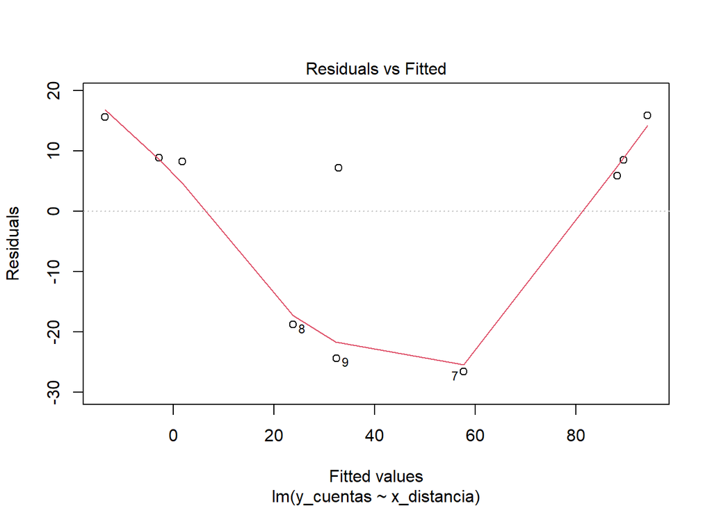

```r
plot(modelo, which = 1)
```

## Ej 22

```r
library(lmtest)
dwtest(modelo, alternative = "two.sided")
```

```
##
##  Durbin-Watson test
##
## data:  modelo
## DW = 0.92072, p-value = 0.05819
## alternative hypothesis: true autocorrelation is not 0
```

## Ej 23

El resultado podría indicar que los errores del modelo no son constantes y que es necesario ajustar el modelo de manera diferente.

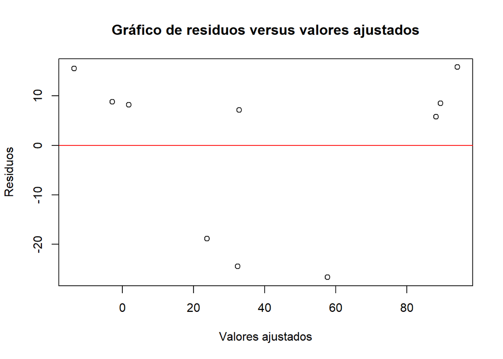

```r
plot(x = modelo$fitted.values, y = modelo$residuals,
     xlab = "Valores ajustados", ylab = "Residuos",
     main = "Gráfico de residuos versus valores ajustados")
abline(h = 0, col = "red")
```